# Supplemental material for the manuscript ‘Assessing covariate-adjusted risk differences in small-sample clinical trials’

Reproducible code for simulation, analysis, tables, and figures

Author

Martin Schnuerch

# About

This document provides supplemental material for the manuscript “*Assessing covariate-adjusted risk differences in clinical trials with small samples*” by **Martin Schnuerch, Alex Ocampo, Klaus Kähler Holst, and Christian Stock**. It contains the complete, reproducible simulation code used to evaluate the statistical methods considered in the manuscript and to generate the figures reported therein.

The simulation framework encompasses the definition of data-generating mechanisms, implementation of estimators and inferential procedures, execution of the simulation study, aggregation of performance measures, and creation of figures for the manuscript. Together with the accompanying source files (stored in `R/` and `src/` sub-folders), this document provides all code necessary to reproduce the simulation, analyses, and all figures.

To facilitate exact computational reproducibility, the supplement concludes with detailed session information specifying the versions of R and all packages used during the analyses.

# Simulation Study

## Required Packages and Helper Functions

```r
# Load required packages
suppressPackageStartupMessages({
  # General
  library(dplyr)
  library(tidyr)
  library(purrr)
  library(parallel)
  library(furrr)
  library(tibble)
  library(Rcpp)
  library(DT)
  library(ggplot2)
  library(grid)
  library(patchwork)
  library(svglite)
  library(clustermq)
  library(foreach)
  library(doRNG)
  library(kableExtra)
  # Specific Analyses
  library(RobinCar)
  library(Exact)
  library(sandwich)
  library(margins)
  library(marginaleffects)
  library(detectseparation)
  library(logistf)
  #library(fastglm)
})

# Source helper scripts

# source helper scripts from R/
for (f in list.files("R", pattern = "\\.R$", full.names = TRUE)) {
  source(f)
}

# source helper scripts from src/
for (f in list.files("src", pattern = "\\.cpp$", full.names = TRUE)) {
  sourceCpp(f)
}

# Set cluster options
options(clustermq.scheduler = "slurm")
```

## Simulation Parameters

```r
# Total sample sizes
n <- seq(30, 150, 30)

# Proportion/prevalence/response rate in control group
prev <- .2

# Difference of treatment group to control
diff <- c(0, .15, .3)

# Define distribution for each covariate
cov_rng <- list(
  c("rbinom", "rbinom")
)

# Set parameters for distribution functions specified above (skip n)
cov_pars <- list(
  list(
    c(size = 1, prob = .5),
    c(size = 1, prob = .5)
  )
)

# True regression weights of covariates
cov_coefs <- list(
  "none" = log(c(1, 1)),
  "medium" = log(c(1.5, 1.5)),
  "high" = log(c(3, 3))
)

# Randomization scheme
rand <- "simple"

# Treatment allocation
treat_alloc <- list(
  c(1,1)
)

# Create all possible factor combinations
scenarios <- expand_grid(
  n,
  prev,
  diff,
  cov_rng,
  cov_pars,
  cov_coefs,
  rand,
  treat_alloc
)
scenarios <- scenarios |>
  mutate(
    pop_coefs = purrr::pmap(scenarios[,2:6], def_population_coefs)
  )
```

To evaluate the chosen parameter values, we can check the implied (conditional and marginal) probabilities across treatment groups and covariates:

```r
# define helper function
get_prob <- function(x1, x2, z, pop_coefs, cov_coefs) {

  b0 <- unlist(pop_coefs)[1]
  bz <- unlist(pop_coefs)[2]
  b1 <- unlist(cov_coefs)[1]
  b2 <- unlist(cov_coefs)[2]
  plogis(b0 + z * bz + x1 * b1 + x2 * b2)

}

# output matrix
out <- matrix(nrow = 18, ncol = 7)

for (s in 1:9) {

  # temporary array of probabilities
  tmp <- array(dim = c(2, 2, 2))

  for (i in 1:2) {
    tmp[,,i] <- outer(
      X = c(0, 1),
      Y = c(0, 1),
      FUN = get_prob,
      z = c(0, 1)[i],
      pop_coefs = scenarios[s, "pop_coefs"],
      cov_coefs = scenarios[s, "cov_coefs"]
    )
  }

  # calculate marginal probabilities and marginal effect
  marg_x_0 <- mean(tmp[1,,]) |> rep(2)
  marg_x_1 <- mean(tmp[2,,]) |> rep(2)
  me_x <- (mean(tmp[2,,]) - mean(tmp[1,,])) |> rep(2)

  # combine
  out[((s - 1) * 2 + 1):(s*2),] <- cbind(
    tmp[,,1], tmp[,,2],
    marg_x_0, marg_x_1, me_x
  ) |> round(digits = 2)

}

# Prepare output table
data.frame(
  rep(c("0", "0.15", "0.30"), each = 6),
  rep(c("log(1)", "log(1.5)", "log(3)"), each = 2, times = 3),
  rep(c("\\[X_1 = 0 \\]", "\\[X_1 = 1 \\]"), times = 9),
  out
) |>
  kable(
    "html",
    col.names = c("\\[ \\text{RD}_A \\]", "\\[ \\beta_1,\\beta_2 \\]", "", rep(c("\\[ X_2 = 0\\]", "\\[ X_2 = 1\\]"), 2),
                  "\\[ E_{X=0}(Y) \\]", "\\[ E_{X=1}(Y) \\]", "\\[ \\text{RD}_X \\]"),
    escape = TRUE,
    digits = 2,
    align = "c"
  ) |>
  kableExtra::collapse_rows(columns = c(1, 2, 8, 9, 10), valign = "middle") |>
  kableExtra::add_header_above(c(" " = 3, "A = 0" = 2, "A = 1" = 2, " " = 3)) |>
  kableExtra::kable_styling()
```

[output not shown]

## Run the Simulation

```r
# 1) Use an RNG suitable for parallel streams
RNGkind("L'Ecuyer-CMRG")   # Recommended for reproducible parallel RNG

# 2) Set a single, top-level seed ONCE
set.seed(20260119)

# 3) Set simulation parameters
replications <- 5e4
chunk_size <- 1250
chunks <- ceiling(replications / chunk_size)
total_jobs <- nrow(scenarios) * chunks

# 4) Register clustermq backend
register_dopar_cmq(
  n_jobs = total_jobs,
  memory = 4096,
  export = mget(ls(envir = .GlobalEnv), envir = .GlobalEnv)
)

# 5) Start simulation
start_time <- Sys.time()

res <- foreach(job = 1:total_jobs, .combine = 'rbind',
               .options.RNG = 20260119) %dorng% {

  # Compute scenario and chunk index
  scenario_id <- ((job - 1) %/% chunks) + 1
  chunk_id <- ((job - 1) %% chunks) + 1

  # Run the chunk
  single_scenario(
    n_sim = chunk_size,
    params = scenarios[scenario_id, ],
    methods = c(
      "compute_suissa_shuster", "compute_cmh", "compute_mh_sato",
      "compute_mh_mgr", "compute_ge", "compute_ye", "compute_liu",
      "compute_g_firth", "compute_score_test", "compute_boot"
    ),
    alpha = 0.05,
    type_Ge = "orig",
    type_Liu = "HC3",
    flic = TRUE,
    R = 1000,
    boot_strat = FALSE
  )

}

# End simulation
end_time <- Sys.time()

# Total duration
end_time - start_time
```

```
Time difference of 1.056987 hours
```

Save the raw simulation results:

```r
saveRDS(object = res, file = "sim_results.rds")
```

# Results

Prepare raw results for further analysis:

```r
res <- res |>
  mutate(
    id = rep(seq_len(replications * nrow(scenarios)), each = 10),
    cov_prog_val = sapply(
      `list(cov_coefs)`,
      \(x) ifelse(
        identical(x, log(rep(1, 2))),
        "none",
        ifelse(
          identical(x, log(rep(1.5, 2))),
          "medium",
          "high"
        )
      )
    ),
    bias = rd_est - diff,
    coverage = dplyr::between(diff, rd_lcl, rd_ucl),
    reject = rd_pval < .05
  ) |>
  group_by(id) |>
  mutate(
    converged = na.omit(converged) |> unique(),
    separation = na.omit(separation) |> unique(),
    separation_treatment = na.omit(separation_treatment) |> unique()
  )
```

```r
plot_data <- res |>
  filter(converged) |>
  group_by(n, diff, cov_prog_val, method) |>
  summarize(
    bias_mean = mean(bias, na.rm = TRUE),
    rmse = sqrt(mean(bias^2, na.rm = TRUE)),
    coverage = mean(coverage, na.rm = TRUE),
    power = mean(reject, na.rm = TRUE),
    n_cases = n(),
    .groups = "drop"
  ) |>
  mutate(
    cov_lab = factor(cov_prog_val,
                     levels = c("none", "medium", "high"),
                     labels = c("beta[1*','*2]==plain('log')(1)",
                                "beta[1*','*2]==plain('log')(1.5)",
                                "beta[1*','*2]==plain('log')(3)")
    )
  )
```

## Figure 1: Separation Issues

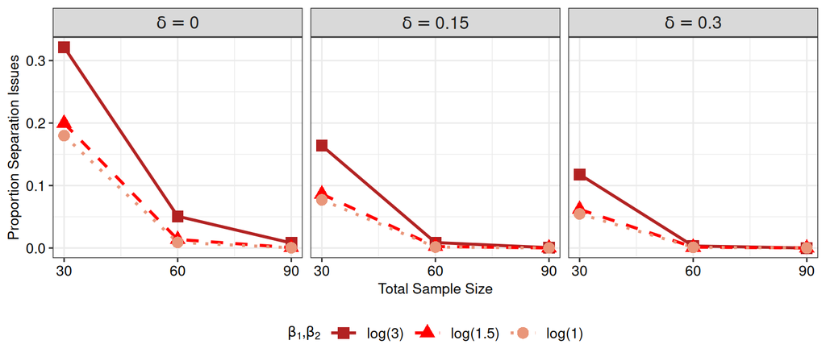

Figure 1

```r
rd <- c(
  "0"    = "delta==0",
  "0.15" = "delta==0.15",
  "0.3" = "delta==0.30"
)

labeller_rd <- as_labeller(rd, label_parsed)

res |>
  group_by(n, diff, cov_prog_val) |>
  summarize(
    separation = mean(separation),
    .groups = "drop"
  ) |>
  mutate(diff = as.character(diff)) |>
  filter(n < 100) |>
  mutate(cov_prog_val = factor(
    cov_prog_val,
    levels = c("high", "medium", "none"),
    labels = c("log(3)", "log(1.5)", "log(1)"))) |>
  ggplot(aes(x = n, y = separation,
             linetype = cov_prog_val,
             shape = cov_prog_val,
             color = cov_prog_val)) +
  facet_wrap(~ diff, labeller = labeller_rd) +
  geom_line(lwd = 1) +
  geom_point(size = 3.5) +
  scale_x_continuous(
    limits = c(30, 90),
    breaks = c(30, 60, 90)
  ) +
  scale_linetype_manual(
    expression(paste(beta[1],",",beta[2])),
    values = c("solid", "dashed", "dotted")
  ) +
  scale_shape_manual(
    expression(paste(beta[1],",",beta[2])),
    values = c(15, 17, 16)
  ) +
  scale_color_manual(
    expression(paste(beta[1],",",beta[2])),
    values = c("firebrick", "red", "darksalmon")
  ) +
  labs(
    x = "Total Sample Size",
    y = "Proportion Separation Issues"
  ) +
  theme_bw() +
  theme(
    text = element_text(size = 10, color = "black"),
    legend.position = "bottom",
    legend.key.width = unit(1.5, "lines"),
    axis.text = element_text(size = 10, color = "black"),
    strip.text = element_text(size = 12),
    legend.text = element_text(size = 10)
  )

ggsave("figures/separation.pdf", width = 8, height = 3.5)
```

## Figure 2: Operating Characteristics

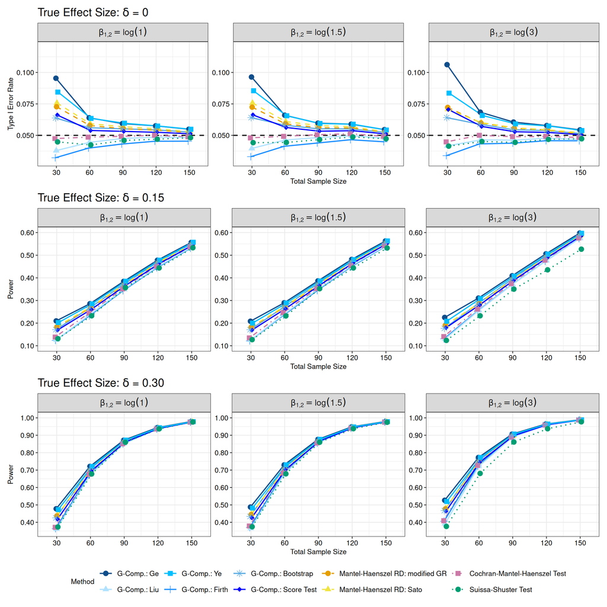

Figure 2

```r
plot_dat <- plot_data

# Gather methods and organize in clusters
breaks <- c(
  "Ge (orig)", "Liu (HC3)", "Ye", "Firth (FLIC)", "g-comp bootstrap", "Score Test",
  "MH (mGR)", "MH (Sato)", "cmh test", "suissa-shuster"
)

# Set labels
labels <- c(
  "G-Comp.: Ge",
  "G-Comp.: Liu",
  "G-Comp.: Ye",
  "G-Comp.: Firth",
  "G-Comp.: Bootstrap",
  "G-Comp.: Score Test",
  "Mantel-Haenszel RD: modified GR",
  "Mantel-Haenszel RD: Sato",
  "Cochran-Mantel-Haenszel Test",
  "Suissa-Shuster Test"
)

# Set colors: unique per method, grouped by clusters
values <- c(
  "dodgerblue4", "lightskyblue1", "deepskyblue", "dodgerblue", "#5DADE2", "blue",  # G-Comp (blue family)
  "#E69F00", "#F0E442",                                              # MH (orange/yellow)
  "#CC79A7",                                                         # Suissa-Shuster (magenta)
  "#009E73"                                                          # CMH (green)
)

# Linetypes: Same within cluster, different across clusters
line_types <- c(
  rep("solid", 6),      # G-Comp
  rep("dashed", 2),     # MH
  "dotdash",            # CMH
  "dotted"              # Suissa-Shuster
)

# Shapes: Unique within clusters
shapes <- c(19, 17, 15, 3, 8, 18, 19, 17, 15, 19)

###

a <- plot_dat |>
  mutate(cov_lab = factor(cov_lab)) |>
  filter(diff == 0) |>
  ggplot(aes(x = n, y = power, group = method)) +
  facet_wrap(
    ~ cov_lab,
    scales = "free_y",
    labeller = label_parsed
  ) +
  geom_hline(yintercept = .05, linetype = "dashed", lwd = .75) +
  geom_line(aes(color = method, linetype = method), linewidth = .8,
            position = position_dodge(width = 3)) +
  geom_point(aes(color = method, shape = method), size = 3,
             position = position_dodge(width = 3)) +
  scale_y_continuous(limits = c(.03, .12)) +
  scale_x_continuous(limits = c(20, 160), breaks = seq(30, 150, 30)) +
  scale_color_manual("Method", breaks = breaks, values = values, labels = labels) +
  scale_linetype_manual("Method", breaks = breaks, values = line_types, labels = labels) +
  scale_shape_manual("Method", breaks = breaks, values = shapes, labels = labels) +
  labs(x = "Total Sample Size",
       y = "Type I Error Rate",
       title = expression(paste("True Effect Size: ", delta, " = 0"))) +
  theme_bw() +
  theme(
    text = element_text(size = 10, color = "black"),
    legend.position = "bottom",
    legend.key.width = unit(1.5, "lines"),
    axis.text = element_text(size = 10, color = "black"),
    panel.spacing.y = unit(0.6, "lines"),
    plot.title = element_text(
      hjust = 0,           # 0 = left, 1 = right, 0.5 = center
      size = 16,           # increase font size
      face = "bold"        # bold title
    ),
    strip.text = element_text(size = 12),
    legend.text = element_text(size = 10)
  )

b <- plot_dat |>
  filter(diff == .15) |>
  ggplot(aes(x = n, y = power, group = method)) +
  facet_wrap(
    ~ cov_lab,
    scales = "free_y",
    labeller = label_parsed
  ) +
  geom_line(aes(color = method, linetype = method), linewidth = .8,
            position = position_dodge(width = 3)) +
  geom_point(aes(color = method, shape = method), size = 3,
             position = position_dodge(width = 3)) +
  scale_y_continuous(limits = c(.1, .6),
                     breaks = seq(.1, .6, .1),
                     labels = c("0.10", "0.20", "0.30",
                                "0.40", "0.50", "0.60")) +
  scale_x_continuous(limits = c(20, 160), breaks = seq(30, 150, 30)) +
  scale_color_manual("Method", breaks = breaks, values = values, labels = labels) +
  scale_linetype_manual("Method", breaks = breaks, values = line_types, labels = labels) +
  scale_shape_manual("Method", breaks = breaks, values = shapes, labels = labels) +
  labs(x = "Total Sample Size",
       y = "Power",
       title = expression(paste("True Effect Size: ", delta, " = 0.15"))) +
  theme_bw() +
  theme(
    text = element_text(size = 10, color = "black"),
    legend.position = "bottom",
    legend.key.width = unit(1.5, "lines"),
    axis.text = element_text(size = 10, color = "black"),
    panel.spacing.y = unit(0.6, "lines"),
    plot.title = element_text(
      hjust = 0,           # 0 = left, 1 = right, 0.5 = center
      size = 16,           # increase font size
      face = "bold"        # bold title
    ),
    strip.text = element_text(size = 12),
    legend.text = element_text(size = 10)
  )

c <- plot_dat |>
  filter(diff == .3) |>
  ggplot(aes(x = n, y = power, group = method)) +
  facet_wrap(
    ~ cov_lab,
    scales = "free_y",
    labeller = label_parsed
  ) +
  geom_line(aes(color = method, linetype = method), linewidth = .8,
            position = position_dodge(width = 3)) +
  geom_point(aes(color = method, shape = method), size = 3,
             position = position_dodge(width = 3)) +
  scale_y_continuous(limits = c(.35, 1),
                     breaks = seq(.4, 1, .1),
                     labels = c("0.40", "0.50", "0.60",
                                "0.70", "0.80", "0.90", "1.00")) +
  scale_x_continuous(limits = c(20, 160), breaks = seq(30, 150, 30)) +
  scale_color_manual("Method", breaks = breaks, values = values, labels = labels) +
  scale_linetype_manual("Method", breaks = breaks, values = line_types, labels = labels) +
  scale_shape_manual("Method", breaks = breaks, values = shapes, labels = labels) +
  labs(x = "Total Sample Size",
       y = "Power",
       title = expression(paste("True Effect Size: ", delta, " = 0.30"))) +
  theme_bw() +
  theme(
    text = element_text(size = 10, color = "black"),
    legend.position = "bottom",
    legend.key.width = unit(1.5, "lines"),
    axis.text = element_text(size = 10, color = "black"),
    panel.spacing.y = unit(0.6, "lines"),
    plot.title = element_text(
      hjust = 0,           # 0 = left, 1 = right, 0.5 = center
      size = 16,           # increase font size
      face = "bold"        # bold title
    ),
    strip.text = element_text(size = 12),
    legend.text = element_text(size = 10)
  )


combined <- (a / b / c) +
  plot_layout(guides = "collect") &           # collect legends
  theme(legend.position = "bottom")           # place combined legend

combined

ggsave("figures/operating_characteristics.pdf", width = 12, height = 12)
```

## Figure 3: Coverage

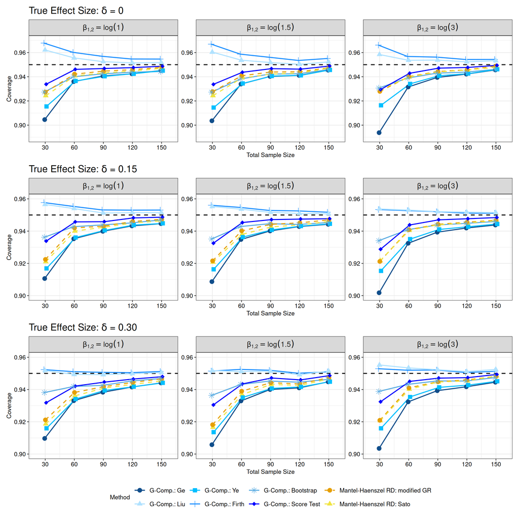

Figure 3

```r
# Filter plot_data to exclude methods without CI
plot_dat <- filter(plot_data, !(method %in% c("suissa-shuster", "cmh test")))

# Gather methods and organize in clusters
breaks <- c(
  "Ge (orig)", "Liu (HC3)", "Ye", "Firth (FLIC)", "g-comp bootstrap", "Score Test",
  "MH (mGR)", "MH (Sato)"
)

# Set labels
labels <- c(
  "G-Comp.: Ge",
  "G-Comp.: Liu",
  "G-Comp.: Ye",
  "G-Comp.: Firth",
  "G-Comp.: Bootstrap",
  "G-Comp.: Score Test",
  "Mantel-Haenszel RD: modified GR",
  "Mantel-Haenszel RD: Sato"
)

# Set colors: unique per method, grouped by clusters
values <- c(
  "dodgerblue4", "lightskyblue1", "deepskyblue", "dodgerblue", "#5DADE2", "blue",  # G-Comp (blue family)
  "#E69F00", "#F0E442"                                              # MH (orange/yellow)
)

# Linetypes: Same within cluster, different across clusters
line_types <- c(
  rep("solid", 6),      # G-Comp
  rep("dashed", 2)     # MH
)

# Shapes: Unique within clusters
shapes <- c(19, 17, 15, 3, 8, 18, 19, 17)

###

a <- plot_dat |>
  filter(diff == 0) |>
  ggplot(aes(x = n, y = coverage, group = method)) +
  facet_wrap(
    ~ cov_lab,
    scales = "free_y",
    labeller = label_parsed
  ) +
  geom_hline(yintercept = .95, linetype = "dashed", lwd = .75) +
  geom_line(aes(color = method, linetype = method), linewidth = .8,
            position = position_dodge(width = 3)) +
  geom_point(aes(color = method, shape = method), size = 3,
             position = position_dodge(width = 3)) +
  scale_y_continuous(limits = c(.89, .97),
                     breaks = seq(.90, .96, .02)) +
  scale_x_continuous(limits = c(20, 160), breaks = seq(30, 150, 30)) +
  scale_color_manual("Method", breaks = breaks, values = values, labels = labels) +
  scale_linetype_manual("Method", breaks = breaks, values = line_types, labels = labels) +
  scale_shape_manual("Method", breaks = breaks, values = shapes, labels = labels) +
  labs(x = "Total Sample Size",
       y = "Coverage",
       title = expression(paste("True Effect Size: ", delta, " = 0"))) +
  theme_bw() +
  theme(
    text = element_text(size = 10, color = "black"),
    legend.position = "bottom",
    legend.key.width = unit(1.5, "lines"),
    axis.text = element_text(size = 10, color = "black"),
    panel.spacing.y = unit(0.6, "lines"),
    plot.title = element_text(
      hjust = 0,           # 0 = left, 1 = right, 0.5 = center
      size = 16,           # increase font size
      face = "bold"        # bold title
    ),
    strip.text = element_text(size = 12),
    legend.text = element_text(size = 10)
  )


b <- plot_dat |>
  filter(diff == 0.15) |>
  ggplot(aes(x = n, y = coverage, group = method)) +
  facet_wrap(
    ~ cov_lab,
    scales = "free_y",
    labeller = label_parsed
  ) +
  geom_hline(yintercept = .95, linetype = "dashed", lwd = .75) +
  geom_line(aes(color = method, linetype = method), linewidth = .8,
            position = position_dodge(width = 3)) +
  geom_point(aes(color = method, shape = method), size = 3,
             position = position_dodge(width = 3)) +
  scale_y_continuous(limits = c(.90, .96),
                     breaks = seq(.88, .98, .02)) +
  scale_x_continuous(limits = c(20, 160), breaks = seq(30, 150, 30)) +
  scale_color_manual("Method", breaks = breaks, values = values, labels = labels) +
  scale_linetype_manual("Method", breaks = breaks, values = line_types, labels = labels) +
  scale_shape_manual("Method", breaks = breaks, values = shapes, labels = labels) +
  labs(x = "Total Sample Size",
       y = "Coverage",
       title = expression(paste("True Effect Size: ", delta, " = 0.15"))) +
  theme_bw() +
  theme(
    text = element_text(size = 10, color = "black"),
    legend.position = "bottom",
    legend.key.width = unit(1.5, "lines"),
    axis.text = element_text(size = 10, color = "black"),
    panel.spacing.y = unit(0.6, "lines"),
    plot.title = element_text(
      hjust = 0,           # 0 = left, 1 = right, 0.5 = center
      size = 16,           # increase font size
      face = "bold"        # bold title
    ),
    strip.text = element_text(size = 12),
    legend.text = element_text(size = 10)
  )

c <- plot_dat |>
  filter(diff == 0.3) |>
  ggplot(aes(x = n, y = coverage, group = method)) +
  facet_wrap(
    ~ cov_lab,
    scales = "free_y",
    labeller = label_parsed
  ) +
  geom_hline(yintercept = .95, linetype = "dashed", lwd = .75) +
  geom_line(aes(color = method, linetype = method), linewidth = .8,
            position = position_dodge(width = 3)) +
  geom_point(aes(color = method, shape = method), size = 3,
             position = position_dodge(width = 3)) +
  scale_y_continuous(limits = c(.90, .96),
                     breaks = seq(.88, .98, .02)) +
  scale_x_continuous(limits = c(20, 160), breaks = seq(30, 150, 30)) +
  scale_color_manual("Method", breaks = breaks, values = values, labels = labels) +
  scale_linetype_manual("Method", breaks = breaks, values = line_types, labels = labels) +
  scale_shape_manual("Method", breaks = breaks, values = shapes, labels = labels) +
  labs(x = "Total Sample Size",
       y = "Coverage",
       title = expression(paste("True Effect Size: ", delta, " = 0.30"))) +
  theme_bw() +
  theme(
    text = element_text(size = 10, color = "black"),
    legend.position = "bottom",
    legend.key.width = unit(1.5, "lines"),
    axis.text = element_text(size = 10, color = "black"),
    panel.spacing.y = unit(0.6, "lines"),
    plot.title = element_text(
      hjust = 0,           # 0 = left, 1 = right, 0.5 = center
      size = 16,           # increase font size
      face = "bold"        # bold title
    ),
    strip.text = element_text(size = 12),
    legend.text = element_text(size = 10)
  )


combined <- (a / b / c) +
  plot_layout(guides = "collect") &           # collect legends
  theme(legend.position = "bottom")           # place combined legend

combined

ggsave("figures/coverage.pdf", width = 12, height = 12)
```

## Figure B1: Estimation Bias

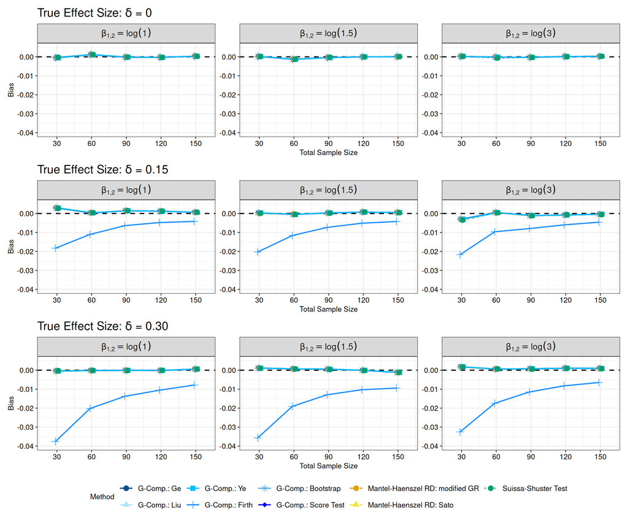

Figure 4

```r
# Filter plot_data to exclude methods without CI
plot_dat <- filter(plot_data, !(method %in% c("cmh test")))

# Gather methods and organize in clusters
breaks <- c(
  "Ge (orig)", "Liu (HC3)", "Ye", "Firth (FLIC)", "g-comp bootstrap", "Score Test",
  "MH (mGR)", "MH (Sato)", "suissa-shuster"
)

# Set labels
labels <- c(
  "G-Comp.: Ge",
  "G-Comp.: Liu",
  "G-Comp.: Ye",
  "G-Comp.: Firth",
  "G-Comp.: Bootstrap",
  "G-Comp.: Score Test",
  "Mantel-Haenszel RD: modified GR",
  "Mantel-Haenszel RD: Sato",
  "Suissa-Shuster Test"
)

# Set colors: unique per method, grouped by clusters
values <- c(
  "dodgerblue4", "lightskyblue1", "deepskyblue", "dodgerblue", "#5DADE2", "blue",  # G-Comp (blue family)
  "#E69F00", "#F0E442",                                              # MH (orange/yellow)
  "#009E73"                                                          # CMH (green)
)

# Linetypes: Same within cluster, different across clusters
line_types <- c(
  rep("solid", 6),      # G-Comp
  rep("dashed", 2),     # MH
  "dotted"              # Suissa-Shuster
)

# Shapes: Unique within clusters
shapes <- c(19, 17, 15, 3, 8, 18, 19, 17, 19)

###

a <- plot_dat |>
  filter(diff == 0) |>
  ggplot(aes(x = n, y = bias_mean, group = method)) +
  facet_wrap(
    ~ cov_lab,
    scales = "free_y",
    labeller = label_parsed
  ) +
  geom_hline(yintercept = 0, linetype = "dashed", lwd = .75) +
  geom_line(aes(color = method, linetype = method), linewidth = .8,
            position = position_dodge(width = 3)) +
  geom_point(aes(color = method, shape = method), size = 3,
             position = position_dodge(width = 3)) +
  scale_y_continuous(limits = c(-.04, .005)) +
  scale_x_continuous(limits = c(20, 160), breaks = seq(30, 150, 30)) +
  scale_color_manual("Method", breaks = breaks, values = values, labels = labels) +
  scale_linetype_manual("Method", breaks = breaks, values = line_types, labels = labels) +
  scale_shape_manual("Method", breaks = breaks, values = shapes, labels = labels) +
  labs(x = "Total Sample Size",
       y = "Bias",
       title = expression(paste("True Effect Size: ", delta, " = 0"))) +
  theme_bw() +
  theme(
    text = element_text(size = 10, color = "black"),
    legend.position = "bottom",
    legend.key.width = unit(1.5, "lines"),
    axis.text = element_text(size = 10, color = "black"),
    panel.spacing.y = unit(0.6, "lines"),
    plot.title = element_text(
      hjust = 0,           # 0 = left, 1 = right, 0.5 = center
      size = 16,           # increase font size
      face = "bold"        # bold title
    ),
    strip.text = element_text(size = 12),
    legend.text = element_text(size = 10)
  )

b <- plot_dat |>
  filter(diff == 0.15) |>
  ggplot(aes(x = n, y = bias_mean, group = method)) +
  facet_wrap(
    ~ cov_lab,
    scales = "free_y",
    labeller = label_parsed
  ) +
  geom_hline(yintercept = 0, linetype = "dashed", lwd = .75) +
  geom_line(aes(color = method, linetype = method), linewidth = .8,
            position = position_dodge(width = 3)) +
  geom_point(aes(color = method, shape = method), size = 3,
             position = position_dodge(width = 3)) +
  scale_y_continuous(limits = c(-.04, .005)) +
  scale_x_continuous(limits = c(20, 160), breaks = seq(30, 150, 30)) +
  scale_color_manual("Method", breaks = breaks, values = values, labels = labels) +
  scale_linetype_manual("Method", breaks = breaks, values = line_types, labels = labels) +
  scale_shape_manual("Method", breaks = breaks, values = shapes, labels = labels) +
  labs(x = "Total Sample Size",
       y = "Bias",
       title = expression(paste("True Effect Size: ", delta, " = 0.15"))) +
  theme_bw() +
  theme(
    text = element_text(size = 10, color = "black"),
    legend.position = "bottom",
    legend.key.width = unit(1.5, "lines"),
    axis.text = element_text(size = 10, color = "black"),
    panel.spacing.y = unit(0.6, "lines"),
    plot.title = element_text(
      hjust = 0,           # 0 = left, 1 = right, 0.5 = center
      size = 16,           # increase font size
      face = "bold"        # bold title
    ),
    strip.text = element_text(size = 12),
    legend.text = element_text(size = 10)
  )

c <- plot_dat |>
  filter(diff == 0.3) |>
  ggplot(aes(x = n, y = bias_mean, group = method)) +
  facet_wrap(
    ~ cov_lab,
    scales = "free_y",
    labeller = label_parsed
  ) +
  geom_hline(yintercept = 0, linetype = "dashed", lwd = .75) +
  geom_line(aes(color = method, linetype = method), linewidth = .8,
            position = position_dodge(width = 3)) +
  geom_point(aes(color = method, shape = method), size = 3,
             position = position_dodge(width = 3)) +
  scale_y_continuous(limits = c(-.04, .005)) +
  scale_x_continuous(limits = c(20, 160), breaks = seq(30, 150, 30)) +
  scale_color_manual("Method", breaks = breaks, values = values, labels = labels) +
  scale_linetype_manual("Method", breaks = breaks, values = line_types, labels = labels) +
  scale_shape_manual("Method", breaks = breaks, values = shapes, labels = labels) +
  labs(x = "Total Sample Size",
       y = "Bias",
       title = expression(paste("True Effect Size: ", delta, " = 0.30"))) +
  theme_bw() +
  theme(
    text = element_text(size = 10, color = "black"),
    legend.position = "bottom",
    legend.key.width = unit(1.5, "lines"),
    axis.text = element_text(size = 10, color = "black"),
    panel.spacing.y = unit(0.6, "lines"),
    plot.title = element_text(
      hjust = 0,           # 0 = left, 1 = right, 0.5 = center
      size = 16,           # increase font size
      face = "bold"        # bold title
    ),
    strip.text = element_text(size = 12),
    legend.text = element_text(size = 10)
  )


combined <- (a / b / c) +
  plot_layout(guides = "collect") &           # collect legends
  theme(legend.position = "bottom")           # place combined legend

combined

ggsave("figures/estimation_bias.pdf", width = 12, height = 10)
```

## Figure B2: RMSE

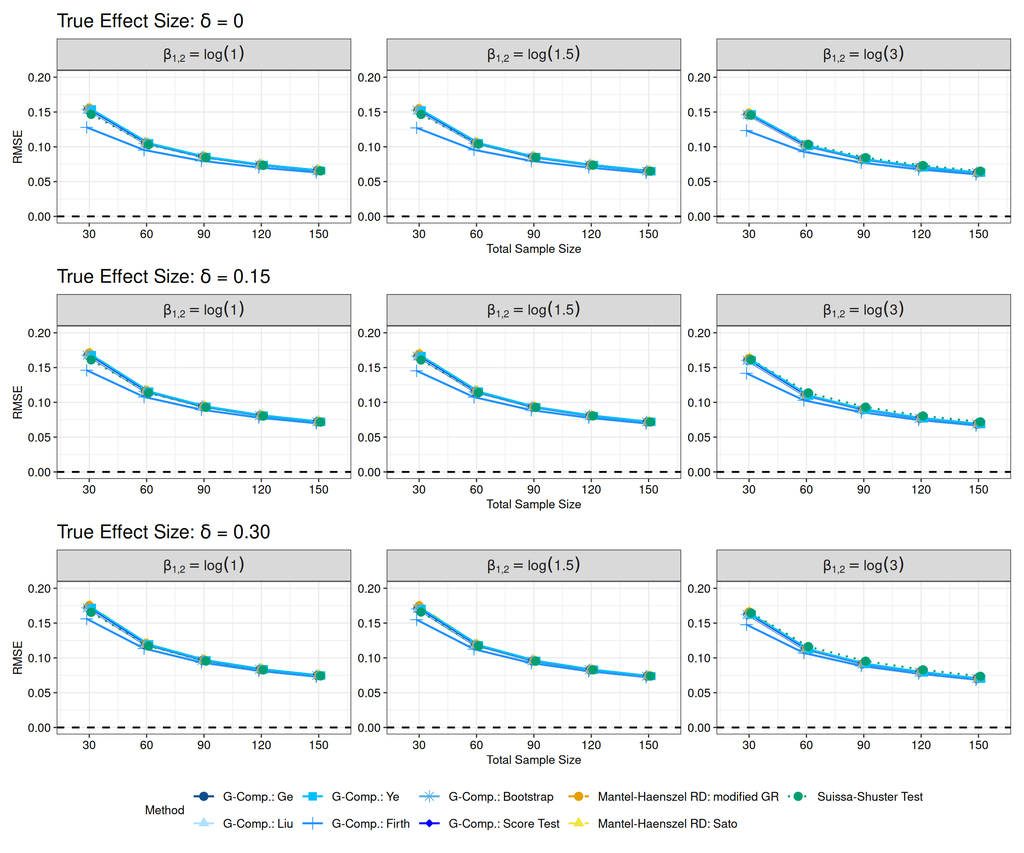

Figure 5

```r
# Filter plot_data to exclude methods without CI
plot_dat <- filter(plot_data, !(method %in% c("cmh test")))

# Gather methods and organize in clusters
breaks <- c(
  "Ge (orig)", "Liu (HC3)", "Ye", "Firth (FLIC)", "g-comp bootstrap", "Score Test",
  "MH (mGR)", "MH (Sato)", "suissa-shuster"
)

# Set labels
labels <- c(
  "G-Comp.: Ge",
  "G-Comp.: Liu",
  "G-Comp.: Ye",
  "G-Comp.: Firth",
  "G-Comp.: Bootstrap",
  "G-Comp.: Score Test",
  "Mantel-Haenszel RD: modified GR",
  "Mantel-Haenszel RD: Sato",
  "Suissa-Shuster Test"
)

# Set colors: unique per method, grouped by clusters
values <- c(
  "dodgerblue4", "lightskyblue1", "deepskyblue", "dodgerblue", "#5DADE2", "blue",  # G-Comp (blue family)
  "#E69F00", "#F0E442",                                              # MH (orange/yellow)
  "#009E73"                                                          # CMH (green)
)

# Linetypes: Same within cluster, different across clusters
line_types <- c(
  rep("solid", 6),      # G-Comp
  rep("dashed", 2),     # MH
  "dotted"              # Suissa-Shuster
)

# Shapes: Unique within clusters
shapes <- c(19, 17, 15, 3, 8, 18, 19, 17, 19)

###

a <- plot_dat |>
  filter(diff == 0) |>
  ggplot(aes(x = n, y = rmse, group = method)) +
  facet_wrap(
    ~ cov_lab,
    scales = "free_y",
    labeller = label_parsed
  ) +
  geom_hline(yintercept = 0, linetype = "dashed", lwd = .75) +
  geom_line(aes(color = method, linetype = method), linewidth = .8,
            position = position_dodge(width = 3)) +
  geom_point(aes(color = method, shape = method), size = 3,
             position = position_dodge(width = 3)) +
  scale_y_continuous(limits = c(0, .2)) +
  scale_x_continuous(limits = c(20, 160), breaks = seq(30, 150, 30)) +
  scale_color_manual("Method", breaks = breaks, values = values, labels = labels) +
  scale_linetype_manual("Method", breaks = breaks, values = line_types, labels = labels) +
  scale_shape_manual("Method", breaks = breaks, values = shapes, labels = labels) +
  labs(x = "Total Sample Size",
       y = "RMSE",
       title = expression(paste("True Effect Size: ", delta, " = 0"))) +
  theme_bw() +
  theme(
    text = element_text(size = 10, color = "black"),
    legend.position = "bottom",
    legend.key.width = unit(1.5, "lines"),
    axis.text = element_text(size = 10, color = "black"),
    panel.spacing.y = unit(0.6, "lines"),
    plot.title = element_text(
      hjust = 0,           # 0 = left, 1 = right, 0.5 = center
      size = 16,           # increase font size
      face = "bold"        # bold title
    ),
    strip.text = element_text(size = 12),
    legend.text = element_text(size = 10)
  )

b <- plot_dat |>
  filter(diff == 0.15) |>
  ggplot(aes(x = n, y = rmse, group = method)) +
  facet_wrap(
    ~ cov_lab,
    scales = "free_y",
    labeller = label_parsed
  ) +
  geom_hline(yintercept = 0, linetype = "dashed", lwd = .75) +
  geom_line(aes(color = method, linetype = method), linewidth = .8,
            position = position_dodge(width = 3)) +
  geom_point(aes(color = method, shape = method), size = 3,
             position = position_dodge(width = 3)) +
  scale_y_continuous(limits = c(0, .2)) +
  scale_x_continuous(limits = c(20, 160), breaks = seq(30, 150, 30)) +
  scale_color_manual("Method", breaks = breaks, values = values, labels = labels) +
  scale_linetype_manual("Method", breaks = breaks, values = line_types, labels = labels) +
  scale_shape_manual("Method", breaks = breaks, values = shapes, labels = labels) +
  labs(x = "Total Sample Size",
       y = "RMSE",
       title = expression(paste("True Effect Size: ", delta, " = 0.15"))) +
  theme_bw() +
  theme(
    text = element_text(size = 10, color = "black"),
    legend.position = "bottom",
    legend.key.width = unit(1.5, "lines"),
    axis.text = element_text(size = 10, color = "black"),
    panel.spacing.y = unit(0.6, "lines"),
    plot.title = element_text(
      hjust = 0,           # 0 = left, 1 = right, 0.5 = center
      size = 16,           # increase font size
      face = "bold"        # bold title
    ),
    strip.text = element_text(size = 12),
    legend.text = element_text(size = 10)
  )

c <- plot_dat |>
  filter(diff == 0.3) |>
  ggplot(aes(x = n, y = rmse, group = method)) +
  facet_wrap(
    ~ cov_lab,
    scales = "free_y",
    labeller = label_parsed
  ) +
  geom_hline(yintercept = 0, linetype = "dashed", lwd = .75) +
  geom_line(aes(color = method, linetype = method), linewidth = .8,
            position = position_dodge(width = 3)) +
  geom_point(aes(color = method, shape = method), size = 3,
             position = position_dodge(width = 3)) +
  scale_y_continuous(limits = c(0, .2)) +
  scale_x_continuous(limits = c(20, 160), breaks = seq(30, 150, 30)) +
  scale_color_manual("Method", breaks = breaks, values = values, labels = labels) +
  scale_linetype_manual("Method", breaks = breaks, values = line_types, labels = labels) +
  scale_shape_manual("Method", breaks = breaks, values = shapes, labels = labels) +
  labs(x = "Total Sample Size",
       y = "RMSE",
       title = expression(paste("True Effect Size: ", delta, " = 0.30"))) +
  theme_bw() +
  theme(
    text = element_text(size = 10, color = "black"),
    legend.position = "bottom",
    legend.key.width = unit(1.5, "lines"),
    axis.text = element_text(size = 10, color = "black"),
    panel.spacing.y = unit(0.6, "lines"),
    plot.title = element_text(
      hjust = 0,           # 0 = left, 1 = right, 0.5 = center
      size = 16,           # increase font size
      face = "bold"        # bold title
    ),
    strip.text = element_text(size = 12),
    legend.text = element_text(size = 10)
  )


combined <- (a / b / c) +
  plot_layout(guides = "collect") &           # collect legends
  theme(legend.position = "bottom")           # place combined legend

combined

ggsave("figures/rmse.pdf", width = 12, height = 10)
```

[session information not shown]